# Week_14_Project

Nelson Muteti

6/4/2021

# Nelson Muteti : Independent Project Week 14

## 1.1 Defining the Question

**I am a Data analyst at Carrefour Kenya and is currently undertaking a project that will** **inform the marketing department on the most relevant marketing strategies that will result** **in the highest no. of sales (total price including tax).My project has been divided into** **four parts where I’ll explore a recent marketing dataset by performing various** **unsupervised learning techniques and later providing recommendations based on my insights.**

## 1.2 Defining Metrics for Success

**A succesful project will clean the data provided, perform Univariate and Bivariate** **analysis of the variables and finally draw recommendations for the supermarket.**

## 1.3 Understanding The context.

**The context here is mainly about supermarkets and retail based business**

## 1.4 Reading the data

#import some necessary libraries

```r
library(data.table)
```

```r
library(dplyr)
```

```r
library(ggplot2)
```

```r
library(tidyverse)
```

**Read the data.**

```r
df <- fread("http://bit.ly/CarreFourDataset")
```

```r
head(df)
```

```
##     Invoice ID Branch Customer type Gender           Product line Unit price
## 1: 750-67-8428      A        Member Female      Health and beauty      74.69
## 2: 226-31-3081      C        Normal Female Electronic accessories      15.28
## 3: 631-41-3108      A        Normal   Male     Home and lifestyle      46.33
## 4: 123-19-1176      A        Member   Male      Health and beauty      58.22
## 5: 373-73-7910      A        Normal   Male      Sports and travel      86.31
## 6: 699-14-3026      C        Normal   Male Electronic accessories      85.39
##    Quantity     Tax      Date  Time     Payment   cogs gross margin percentage
## 1:        7 26.1415  1/5/2019 13:08     Ewallet 522.83                4.761905
## 2:        5  3.8200  3/8/2019 10:29        Cash  76.40                4.761905
## 3:        7 16.2155  3/3/2019 13:23 Credit card 324.31                4.761905
## 4:        8 23.2880 1/27/2019 20:33     Ewallet 465.76                4.761905
## 5:        7 30.2085  2/8/2019 10:37     Ewallet 604.17                4.761905
## 6:        7 29.8865 3/25/2019 18:30     Ewallet 597.73                4.761905
##    gross income Rating    Total
## 1:      26.1415    9.1 548.9715
## 2:       3.8200    9.6  80.2200
## 3:      16.2155    7.4 340.5255
## 4:      23.2880    8.4 489.0480
## 5:      30.2085    5.3 634.3785
## 6:      29.8865    4.1 627.6165
```

## 1.5 Data Cleaning

**First objective - Reduce the Dimensionality of dataset.**

**First, clean and validate the data.**

```r
colSums(is.na(df))
```

```
##              Invoice ID                  Branch           Customer type
##                       0                       0                       0
##                  Gender            Product line              Unit price
##                       0                       0                       0
##                Quantity                     Tax                    Date
##                       0                       0                       0
##                    Time                 Payment                    cogs
##                       0                       0                       0
## gross margin percentage            gross income                  Rating
##                       0                       0                       0
##                   Total
##                       0
```

```r
#identifying any missing values in data
```

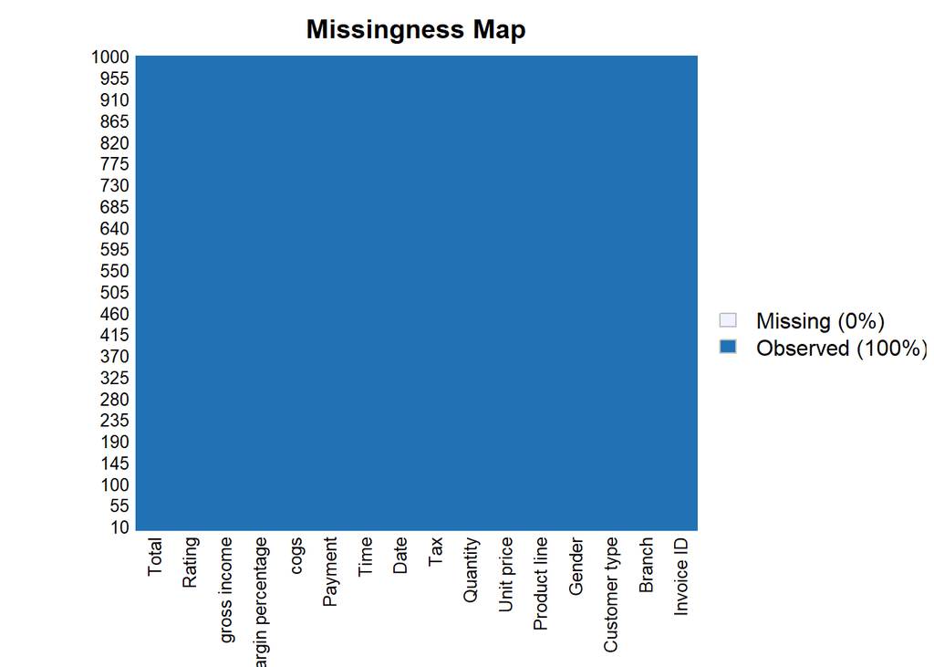

```r
library(Amelia)
missmap(df)
```

**None of the columns have NA values.**

**Remove duplicate data.**

```r
mydf <- unique(df)
dim(df)
```

```
## [1] 1000   16
```

**Original data has 1000 rows and 16 columns.**

```r
dim(mydf)
```

```
## [1] 1000   16
```

**Clean data has 1000 rows and 16 columns too.**

**Get summary of data.**

```r
summary(mydf)
```

```
##   Invoice ID           Branch          Customer type         Gender
##  Length:1000        Length:1000        Length:1000        Length:1000
##  Class :character   Class :character   Class :character   Class :character
##  Mode  :character   Mode  :character   Mode  :character   Mode  :character
##
##
##
##  Product line         Unit price       Quantity          Tax
##  Length:1000        Min.   :10.08   Min.   : 1.00   Min.   : 0.5085
##  Class :character   1st Qu.:32.88   1st Qu.: 3.00   1st Qu.: 5.9249
##  Mode  :character   Median :55.23   Median : 5.00   Median :12.0880
##                     Mean   :55.67   Mean   : 5.51   Mean   :15.3794
##                     3rd Qu.:77.94   3rd Qu.: 8.00   3rd Qu.:22.4453
##                     Max.   :99.96   Max.   :10.00   Max.   :49.6500
##      Date               Time             Payment               cogs
##  Length:1000        Length:1000        Length:1000        Min.   : 10.17
##  Class :character   Class :character   Class :character   1st Qu.:118.50
##  Mode  :character   Mode  :character   Mode  :character   Median :241.76
##                                                           Mean   :307.59
##                                                           3rd Qu.:448.90
##                                                           Max.   :993.00
##  gross margin percentage  gross income         Rating           Total
##  Min.   :4.762           Min.   : 0.5085   Min.   : 4.000   Min.   :  10.68
##  1st Qu.:4.762           1st Qu.: 5.9249   1st Qu.: 5.500   1st Qu.: 124.42
##  Median :4.762           Median :12.0880   Median : 7.000   Median : 253.85
##  Mean   :4.762           Mean   :15.3794   Mean   : 6.973   Mean   : 322.97
##  3rd Qu.:4.762           3rd Qu.:22.4453   3rd Qu.: 8.500   3rd Qu.: 471.35
##  Max.   :4.762           Max.   :49.6500   Max.   :10.000   Max.   :1042.65
```

```r
str(mydf)
```

```
## Classes 'data.table' and 'data.frame':   1000 obs. of  16 variables:
##  $ Invoice ID             : chr  "750-67-8428" "226-31-3081" "631-41-3108" "123-19-1176" ...
##  $ Branch                 : chr  "A" "C" "A" "A" ...
##  $ Customer type          : chr  "Member" "Normal" "Normal" "Member" ...
##  $ Gender                 : chr  "Female" "Female" "Male" "Male" ...
##  $ Product line           : chr  "Health and beauty" "Electronic accessories" "Home and lifestyle" "Health and beauty" ...
##  $ Unit price             : num  74.7 15.3 46.3 58.2 86.3 ...
##  $ Quantity               : int  7 5 7 8 7 7 6 10 2 3 ...
##  $ Tax                    : num  26.14 3.82 16.22 23.29 30.21 ...
##  $ Date                   : chr  "1/5/2019" "3/8/2019" "3/3/2019" "1/27/2019" ...
##  $ Time                   : chr  "13:08" "10:29" "13:23" "20:33" ...
##  $ Payment                : chr  "Ewallet" "Cash" "Credit card" "Ewallet" ...
##  $ cogs                   : num  522.8 76.4 324.3 465.8 604.2 ...
##  $ gross margin percentage: num  4.76 4.76 4.76 4.76 4.76 ...
##  $ gross income           : num  26.14 3.82 16.22 23.29 30.21 ...
##  $ Rating                 : num  9.1 9.6 7.4 8.4 5.3 4.1 5.8 8 7.2 5.9 ...
##  $ Total                  : num  549 80.2 340.5 489 634.4 ...
##  - attr(*, ".internal.selfref")=<externalptr>
```

**Identify outliers in data.**

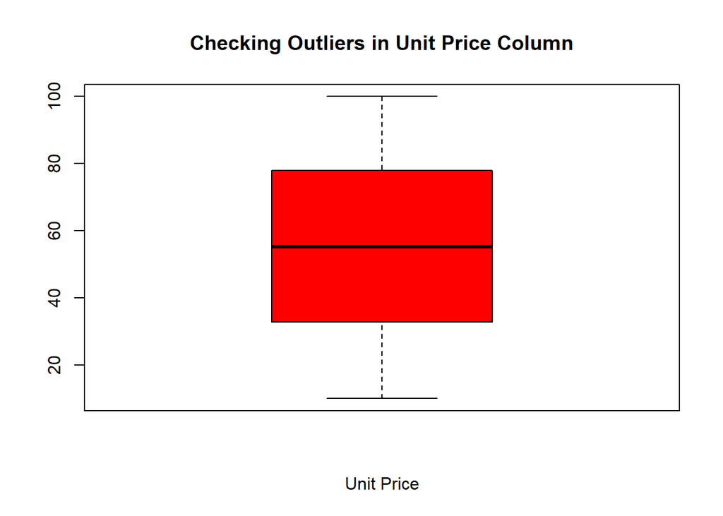

```r
boxplot(mydf$`Unit price`,col = "red",main="Checking Outliers in Unit Price Column",xlab="Unit Price")
```

**There doesnt seem to be any outliers.**

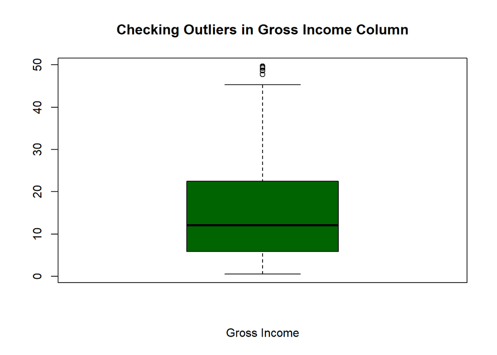

```r
boxplot(mydf$`gross income`,col = "darkgreen",main="Checking Outliers in Gross Income Column",xlab="Gross Income")
```

```r
boxplot.stats(mydf$`gross income`)$out
```

```
## [1] 47.790 49.490 49.650 47.720 48.605 49.260 48.750 48.685 48.690
```

**Just a few outliers which may be important to the data.**

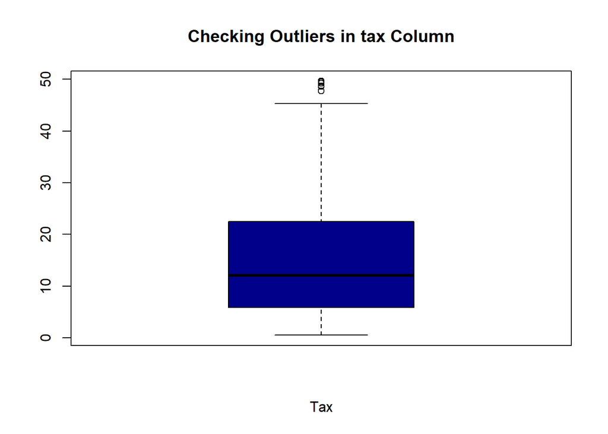

```r
boxplot(mydf$Tax,col = "darkblue",main="Checking Outliers in tax Column",xlab="Tax")
```

**Also some few outliers here but we choose not to drop them since they could be useful in** **analysis.**

## 1.6 Univariate EDA

**Now we proceed to Univariate EDA.**

**First, some descriptive stats about the data.**

```r
#get average quantity of items sold

mean(mydf$Quantity)
```

```
## [1] 5.51
```

**On average, about 5 to 6 pieces are sold per item in the supermarket.**

**Get most popular product line in the supermarket.**

```r
mymod<-function(v){uniqv<-unique(v)
uniqv[which.max(tabulate(match(v,uniqv)))]
}
```

```r
mymod(mydf$`Product line`)
```

```
## [1] "Fashion accessories"
```

**Fashion accessories are the most popular products.**

**Now, get the most popular branch.**

```r
mymod(mydf$Branch)
```

```
## [1] "A"
```

**Branch A seems to be the most recorded for sales.**

**Now, lets find out the different quantiles of tax payments.**

```r
quantile(mydf$Tax)
```

```
##        0%       25%       50%       75%      100%
##  0.508500  5.924875 12.088000 22.445250 49.650000
```

**The median tax per item line is ksh 12.088 /- while the most taxed items accrue about** **49.65 /-**

**Barplot for branches in data.**

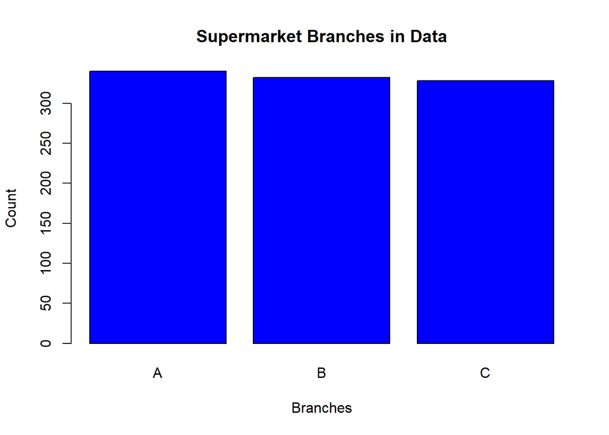

```r
df_branch <- mydf$Branch

df_branch <- table(df_branch)

barplot(df_branch,col = 'blue',xlab = "Branches",ylab = "Count",main = "Supermarket Branches in Data")
```

**Branch A has more visits while C has the least. The difference does not seem to be** **significant.**

**Barplot for product line in data.**

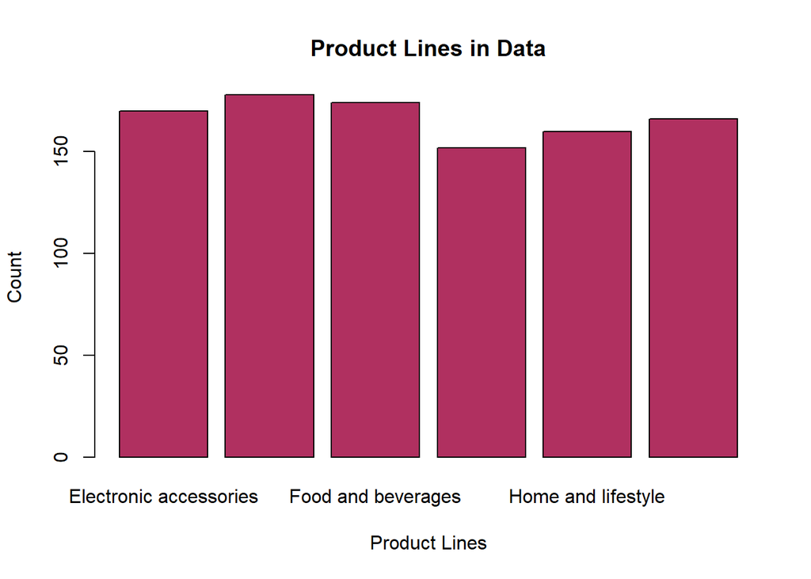

```r
df_prod <- mydf$`Product line`

df_prod <- table(df_prod)

barplot(df_prod,col = 'maroon',xlab = "Product Lines",ylab = "Count",main = "Product Lines in Data")
```

**Health and beauty seem to have the least sale frequencies.**

**Histogram to visulaize distribution of total sales.**

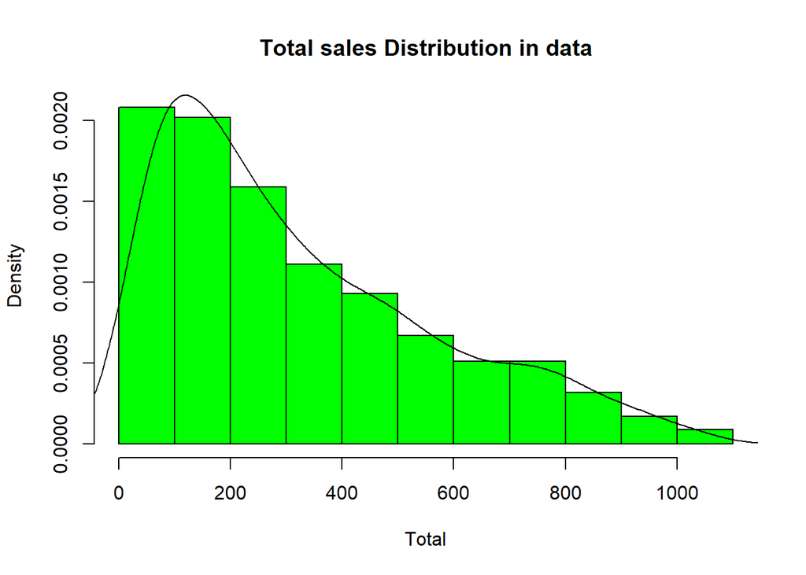

```r
hist(mydf$Total,col = 'green',xlab = 'Total',main = "Total sales Distribution in data",freq = FALSE)

# include a Kernel density estimator line on Histogram

dens <- density(mydf$Total)
# include the KDE line
lines(dens)
```

**Most of the total sales of individual transactions seem to be on the lower end of the** **Kernel density Estimator.**

**As the total sum increases, the transactions reduce and vice-versa.**

**Find skewness of total income.**

```r
library(moments)

skewness(mydf$Total)
```

```
## [1] 0.8912304
```

**The Total column has a strong positive skewness. This means that majority of data points** **lie to the left of the mean.**

## 1.7. Bi-Variate Analysis

**First, a side by side boxplot.**

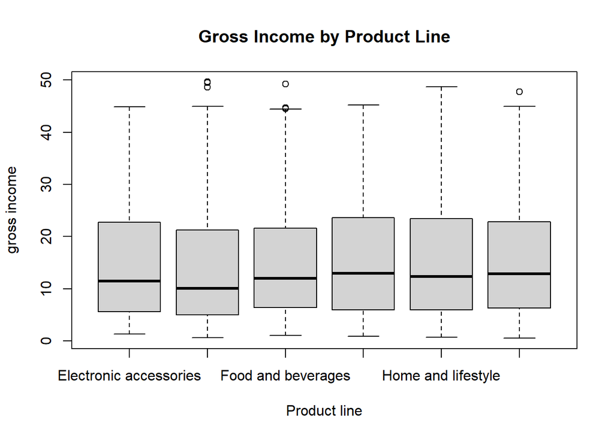

```r
boxplot(`gross income` ~ `Product line`,data = mydf,main = "Gross Income by Product Line",colors(distinct = FALSE))
```

**Health and beauty has the highest average gross income while only recording a few** **transactions.**

**While fashion accessories have the lowest average gross income while recording more** **transations.**

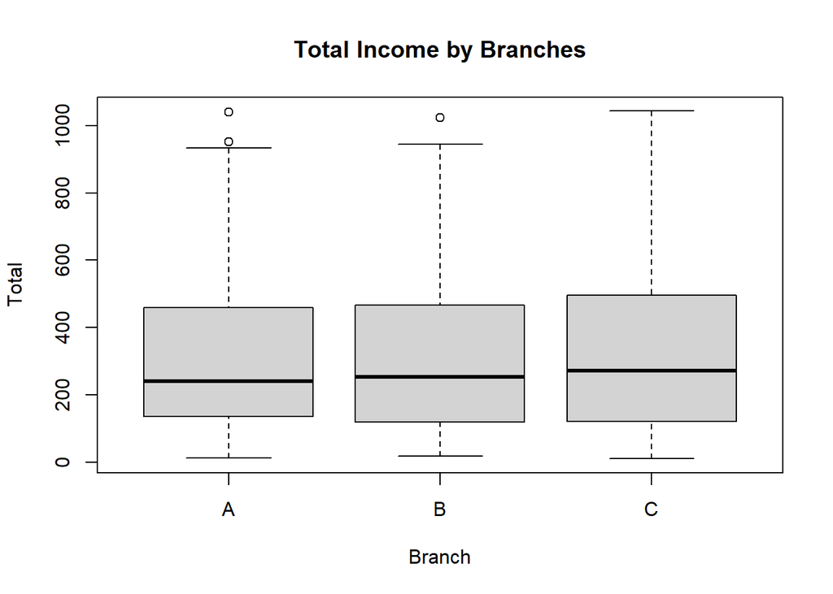

```r
boxplot(Total ~ Branch,data = mydf,main = "Total Income by Branches",colors(distinct = FALSE))
```

**While branch C seems to have a higher average total insome, there is no much difference** **on this criteria.**

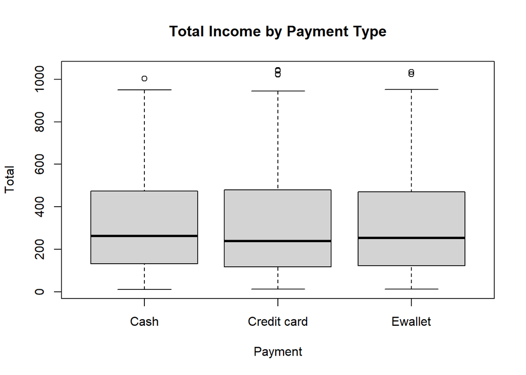

```r
boxplot(Total ~ Payment,data = mydf,main = "Total Income by Payment Type",colors(distinct = FALSE))
```

**Also, no much difference between payment type and total income.**

```r
tapply(mydf$Total,mydf$Gender,mean)
```

```
##   Female     Male
## 335.0957 310.7892
```

**On average, Females spend a bit more than males from the data.**

# **scatter plot**

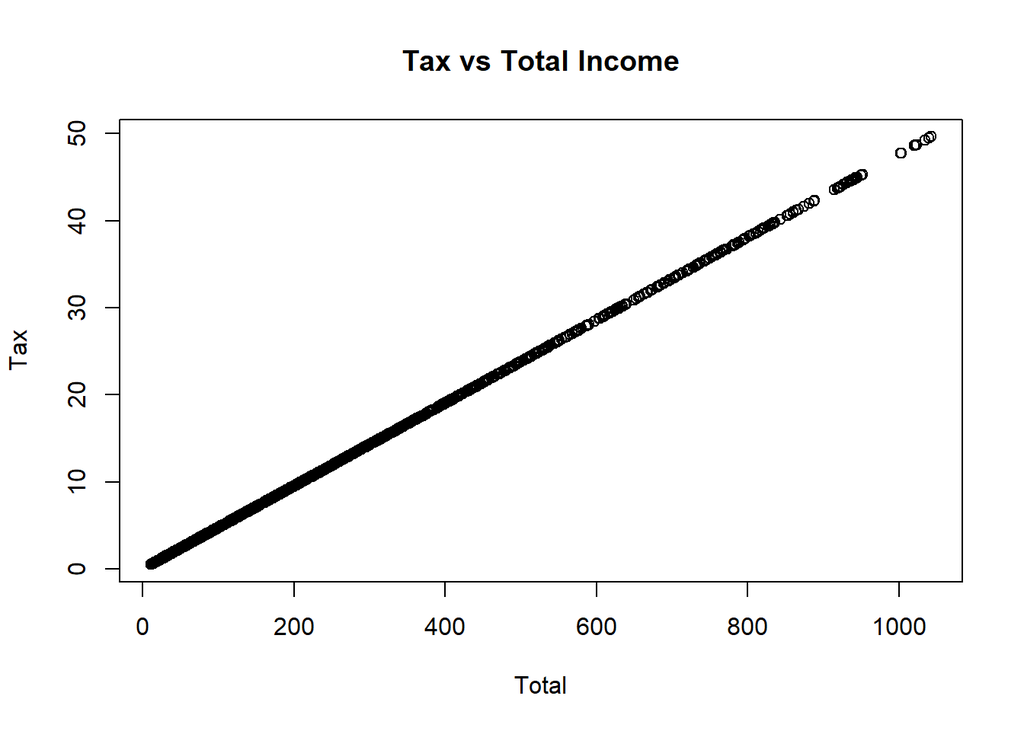

```r
plot(Tax~Total,data = mydf,main = "Tax vs Total Income")
```

**Find correlation.**

```r
cor(mydf$Tax,mydf$Total)
```

```
## [1] 1
```

**The tax and sales are strongly correlated from both the scatter plot and correlation.** **coefficient.**

**Does the rating impact the Total sales.?**

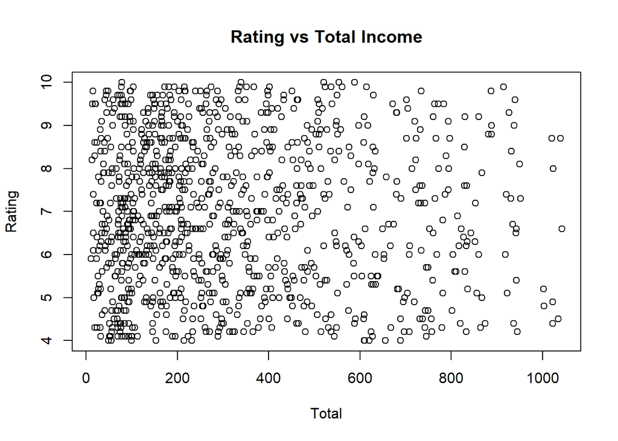

```r
plot(Rating~Total,data = mydf,main = "Rating vs Total Income")
```

```r
# find correlation

cor(mydf$Rating,mydf$Total)
```

```
## [1] -0.0364417
```

**There is no correlation between Product rating and total Income from sales.**

**Pairplots.**

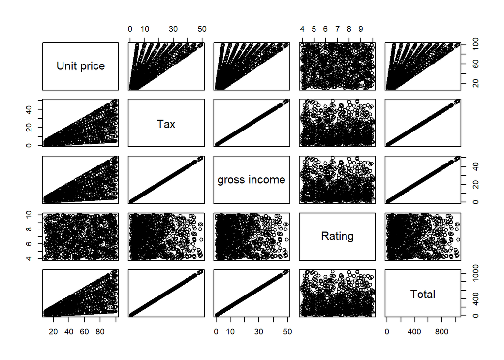

```r
pairs(mydf[,c(6,8,14,15,16)])
```

**Analysis of Branch by Product Line.**

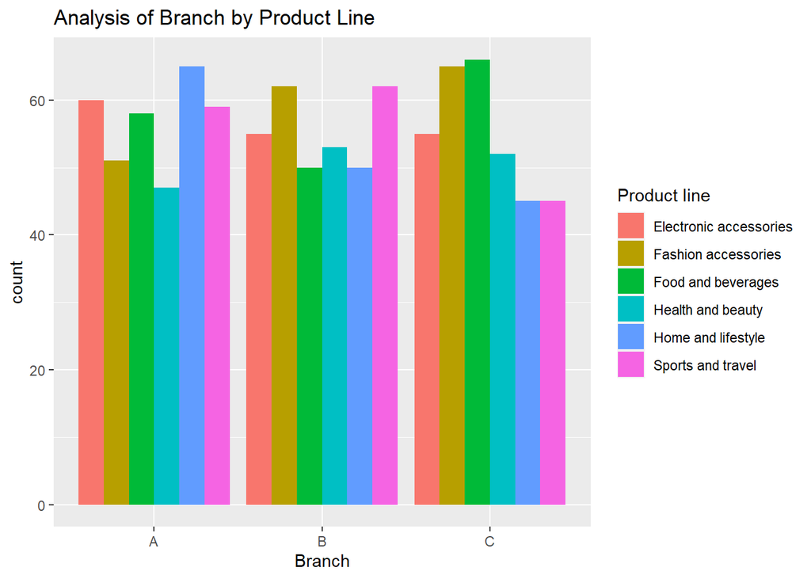

```r
ggplot(mydf,
       aes(x = Branch,
           fill = `Product line`))+
  geom_bar(position = "dodge")+
  labs(title = "Analysis of Branch by Product Line")
```

## 1.8 .Multivariate analysis

**Gross Income vs Unit Price by Product Line.**

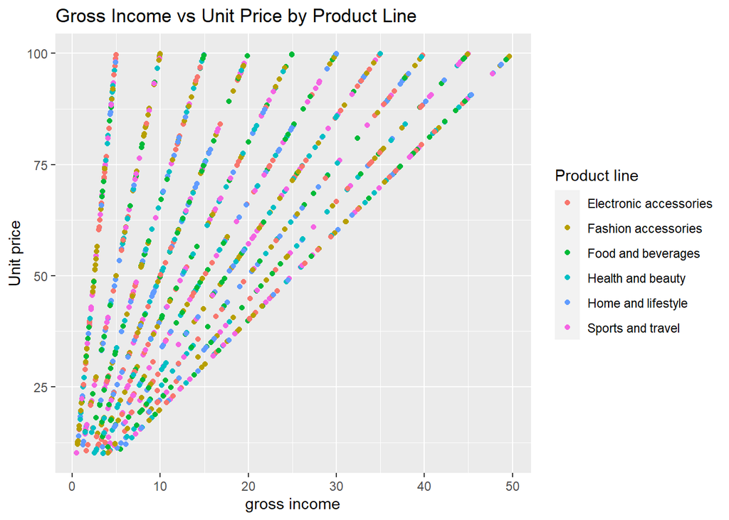

```r
ggplot(mydf,
       aes(x = `gross income`,
           y = `Unit price`,
           color=`Product line`))+
  geom_point()+labs(title = "Gross Income vs Unit Price by Product Line")
```

**Get all correlations for numerical data.**

```r
cor(mydf[,c(6,8,14,15,16,7,12)])
```

```
##                Unit price        Tax gross income       Rating      Total
## Unit price    1.000000000  0.6339621    0.6339621 -0.008777507  0.6339621
## Tax           0.633962089  1.0000000    1.0000000 -0.036441705  1.0000000
## gross income  0.633962089  1.0000000    1.0000000 -0.036441705  1.0000000
## Rating       -0.008777507 -0.0364417   -0.0364417  1.000000000 -0.0364417
## Total         0.633962089  1.0000000    1.0000000 -0.036441705  1.0000000
## Quantity      0.010777564  0.7055102    0.7055102 -0.015814905  0.7055102
## cogs          0.633962089  1.0000000    1.0000000 -0.036441705  1.0000000
##                 Quantity       cogs
## Unit price    0.01077756  0.6339621
## Tax           0.70551019  1.0000000
## gross income  0.70551019  1.0000000
## Rating       -0.01581490 -0.0364417
## Total         0.70551019  1.0000000
## Quantity      1.00000000  0.7055102
## cogs          0.70551019  1.0000000
```

## Part 1.

# **Dimensionality Reduction using PCA.**

**This section of the project entails reducing your dataset to a low dimensional dataset** **using PCA.**

**I will be required to perform your analysis and provide insights gained from my analysis.**

**First, Selecting the numerical data (excluding the categorical variables).**

```r
df1 <-select(mydf,c(6,7,8,12,14,15,16))
```

```r
head(df1)
```

```
##    Unit price Quantity     Tax   cogs gross income Rating    Total
## 1:      74.69        7 26.1415 522.83      26.1415    9.1 548.9715
## 2:      15.28        5  3.8200  76.40       3.8200    9.6  80.2200
## 3:      46.33        7 16.2155 324.31      16.2155    7.4 340.5255
## 4:      58.22        8 23.2880 465.76      23.2880    8.4 489.0480
## 5:      86.31        7 30.2085 604.17      30.2085    5.3 634.3785
## 6:      85.39        7 29.8865 597.73      29.8865    4.1 627.6165
```

**Ascertain data is all numerical.**

```r
str(df1)
```

```
## Classes 'data.table' and 'data.frame':   1000 obs. of  7 variables:
##  $ Unit price  : num  74.7 15.3 46.3 58.2 86.3 ...
##  $ Quantity    : int  7 5 7 8 7 7 6 10 2 3 ...
##  $ Tax         : num  26.14 3.82 16.22 23.29 30.21 ...
##  $ cogs        : num  522.8 76.4 324.3 465.8 604.2 ...
##  $ gross income: num  26.14 3.82 16.22 23.29 30.21 ...
##  $ Rating      : num  9.1 9.6 7.4 8.4 5.3 4.1 5.8 8 7.2 5.9 ...
##  $ Total       : num  549 80.2 340.5 489 634.4 ...
##  - attr(*, ".internal.selfref")=<externalptr>
```

```r
df1$Quantity <- as.numeric(df1$Quantity)
```

```r
str(df1)
```

```
## Classes 'data.table' and 'data.frame':   1000 obs. of  7 variables:
##  $ Unit price  : num  74.7 15.3 46.3 58.2 86.3 ...
##  $ Quantity    : num  7 5 7 8 7 7 6 10 2 3 ...
##  $ Tax         : num  26.14 3.82 16.22 23.29 30.21 ...
##  $ cogs        : num  522.8 76.4 324.3 465.8 604.2 ...
##  $ gross income: num  26.14 3.82 16.22 23.29 30.21 ...
##  $ Rating      : num  9.1 9.6 7.4 8.4 5.3 4.1 5.8 8 7.2 5.9 ...
##  $ Total       : num  549 80.2 340.5 489 634.4 ...
##  - attr(*, ".internal.selfref")=<externalptr>
```

**We then pass df1 to the prcomp(). We also set two arguments, center and scale,**

**to be TRUE then preview our object with summary.**

```r
df1.pca <- prcomp(df1, center = TRUE, scale. = TRUE)
```

**Now that the PCA model is built, lets check importance of components in data.**

```r
summary(df1.pca)
```

```
## Importance of components:
##                           PC1    PC2    PC3     PC4       PC5       PC6
## Standard deviation     2.2185 1.0002 0.9939 0.30001 2.981e-16 1.493e-16
## Proportion of Variance 0.7031 0.1429 0.1411 0.01286 0.000e+00 0.000e+00
## Cumulative Proportion  0.7031 0.8460 0.9871 1.00000 1.000e+00 1.000e+00
##                              PC7
## Standard deviation     9.831e-17
## Proportion of Variance 0.000e+00
## Cumulative Proportion  1.000e+00
```

**We have obtained 7 components.**

**The first component accounts for 70 % of variation in data.**

**The second accounts for about 14 % therefore the first two components account for about**

**84 % of total variation in data.**

**Now, lets find the structure of the PCA object.**

```r
str(df1.pca)
```

```
## List of 5
##  $ sdev    : num [1:7] 2.22 1.00 9.94e-01 3.00e-01 2.98e-16 ...
##  $ rotation: num [1:7, 1:7] -0.292 -0.325 -0.45 -0.45 -0.45 ...
##   ..- attr(*, "dimnames")=List of 2
##   .. ..$ : chr [1:7] "Unit price" "Quantity" "Tax" "cogs" ...
##   .. ..$ : chr [1:7] "PC1" "PC2" "PC3" "PC4" ...
##  $ center  : Named num [1:7] 55.67 5.51 15.38 307.59 15.38 ...
##   ..- attr(*, "names")= chr [1:7] "Unit price" "Quantity" "Tax" "cogs" ...
##  $ scale   : Named num [1:7] 26.49 2.92 11.71 234.18 11.71 ...
##   ..- attr(*, "names")= chr [1:7] "Unit price" "Quantity" "Tax" "cogs" ...
##  $ x       : num [1:1000, 1:7] -2.005 2.306 -0.186 -1.504 -2.8 ...
##   ..- attr(*, "dimnames")=List of 2
##   .. ..$ : NULL
##   .. ..$ : chr [1:7] "PC1" "PC2" "PC3" "PC4" ...
##  - attr(*, "class")= chr "prcomp"
```

**Now we can identify the center values for each of the variables for our PCA.**

```r
df1.pca$center
```

```
##   Unit price     Quantity          Tax         cogs gross income       Rating
##     55.67213      5.51000     15.37937    307.58738     15.37937      6.97270
##        Total
##    322.96675
```

**Finally lets plot the PCA components.**

```r
library(devtools)
```

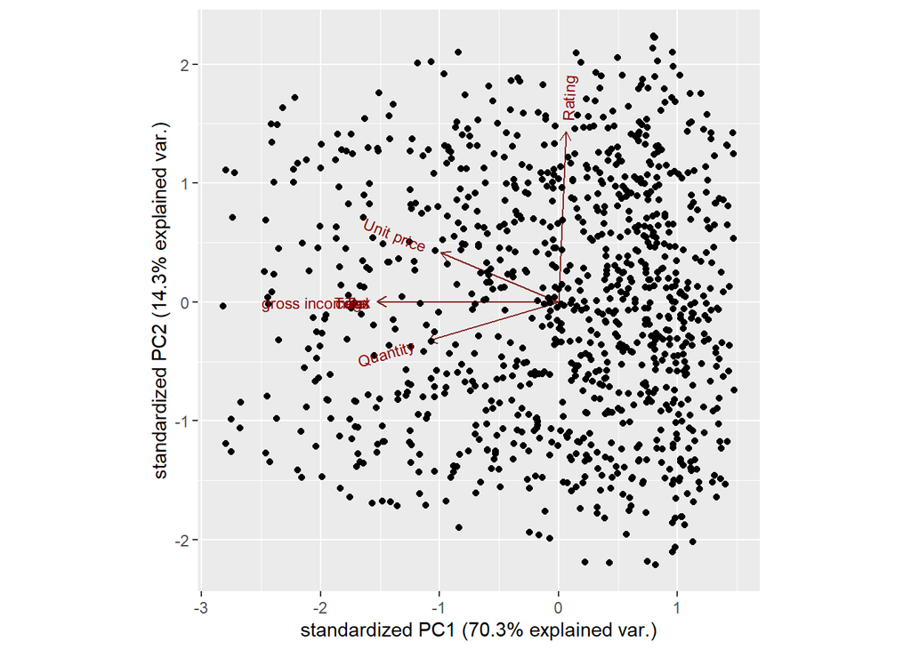

```r
library(ggbiplot)
ggbiplot(df1.pca)
```

## Part 2.

# **Now for Feature Selection.**

**1.)Feature Ranking.**

**We first use the feature ranking library Fselector for this.**

```r
library(FSelector)
```

**First convert some variables to factor.**

```r
mydf$`Customer type` <- as.factor(mydf$`Customer type`)

mydf$Branch <- as.factor(mydf$Branch)

mydf$`Product line` <- as.factor(mydf$`Product line`)

mydf$Gender <- as.factor(mydf$Gender)

mydf$Payment <- as.factor(mydf$Payment)

mydf$Quantity <- as.numeric(mydf$Quantity)
```

```r
str(mydf)
```

```
## Classes 'data.table' and 'data.frame':   1000 obs. of  16 variables:
##  $ Invoice ID             : chr  "750-67-8428" "226-31-3081" "631-41-3108" "123-19-1176" ...
##  $ Branch                 : Factor w/ 3 levels "A","B","C": 1 3 1 1 1 3 1 3 1 2 ...
##  $ Customer type          : Factor w/ 2 levels "Member","Normal": 1 2 2 1 2 2 1 2 1 1 ...
##  $ Gender                 : Factor w/ 2 levels "Female","Male": 1 1 2 2 2 2 1 1 1 1 ...
##  $ Product line           : Factor w/ 6 levels "Electronic accessories",..: 4 1 5 4 6 1 1 5 4 3 ...
##  $ Unit price             : num  74.7 15.3 46.3 58.2 86.3 ...
##  $ Quantity               : num  7 5 7 8 7 7 6 10 2 3 ...
##  $ Tax                    : num  26.14 3.82 16.22 23.29 30.21 ...
##  $ Date                   : chr  "1/5/2019" "3/8/2019" "3/3/2019" "1/27/2019" ...
##  $ Time                   : chr  "13:08" "10:29" "13:23" "20:33" ...
##  $ Payment                : Factor w/ 3 levels "Cash","Credit card",..: 3 1 2 3 3 3 3 3 2 2 ...
##  $ cogs                   : num  522.8 76.4 324.3 465.8 604.2 ...
##  $ gross margin percentage: num  4.76 4.76 4.76 4.76 4.76 ...
##  $ gross income           : num  26.14 3.82 16.22 23.29 30.21 ...
##  $ Rating                 : num  9.1 9.6 7.4 8.4 5.3 4.1 5.8 8 7.2 5.9 ...
##  $ Total                  : num  549 80.2 340.5 489 634.4 ...
##  - attr(*, ".internal.selfref")=<externalptr>
```

**Select data for the ranking process.**

```r
df2 <-select(mydf,c(6,7,8,12,14,15,16))

head(df2)
```

```
##    Unit price Quantity     Tax   cogs gross income Rating    Total
## 1:      74.69        7 26.1415 522.83      26.1415    9.1 548.9715
## 2:      15.28        5  3.8200  76.40       3.8200    9.6  80.2200
## 3:      46.33        7 16.2155 324.31      16.2155    7.4 340.5255
## 4:      58.22        8 23.2880 465.76      23.2880    8.4 489.0480
## 5:      86.31        7 30.2085 604.17      30.2085    5.3 634.3785
## 6:      85.39        7 29.8865 597.73      29.8865    4.1 627.6165
```

```r
Scores <- linear.correlation(Total~.,df2)

Scores
```

```
##              attr_importance
## Unit price         0.6339621
## Quantity           0.7055102
## Tax                1.0000000
## cogs               1.0000000
## gross income       1.0000000
## Rating             0.0364417
```

**Now, lets define a cut off point for the 3 most important attributes.**

```r
imp_variables <- cutoff.k(Scores, 3)

as.data.frame(imp_variables)
```

```
##   imp_variables
## 1           Tax
## 2          cogs
## 3  gross income
```

**The most important features from data are Tax, cogs and gross income.**

**Now lets choose variables by information gain / entropy.**

```r
Scores2 <- information.gain(Total~.,df2)

Scores2
```

```
##              attr_importance
## Unit price         0.3084863
## Quantity           0.4211154
## Tax                1.6094379
## cogs               1.6094379
## gross income       1.6094379
## Rating             0.0000000
```

**Defining the cut off for the three most important variables.**

```r
imp_variables_entropy <- cutoff.k(Scores2, 3)

as.data.frame(imp_variables_entropy)
```

```
##   imp_variables_entropy
## 1                   Tax
## 2                  cogs
## 3          gross income
```

**Tax , cogs and gross income are still the most important attributes.**

# **2.) Filter Methods .**

**Use correlation plots to understand the variables that are highly correlated.**

```r
library(caret)
```

```r
library(corrplot)
head(df2)
```

```
##    Unit price Quantity     Tax   cogs gross income Rating    Total
## 1:      74.69        7 26.1415 522.83      26.1415    9.1 548.9715
## 2:      15.28        5  3.8200  76.40       3.8200    9.6  80.2200
## 3:      46.33        7 16.2155 324.31      16.2155    7.4 340.5255
## 4:      58.22        8 23.2880 465.76      23.2880    8.4 489.0480
## 5:      86.31        7 30.2085 604.17      30.2085    5.3 634.3785
## 6:      85.39        7 29.8865 597.73      29.8865    4.1 627.6165
```

**Now calculate correlation Matrix.**

```r
correlationMatrix <- cor(df2)
```

**Next, we find attributes that are highly correlated.**

```r
highlyCorrelated <- findCorrelation(correlationMatrix, cutoff=0.75)
```

**List the highly correlated attributes.**

```r
highlyCorrelated
```

```
## [1] 4 7 3
```

```r
df3 <- select(df2,c(1,2,6,7))
```

```r
head(df3)
```

```
##    Unit price Quantity Rating    Total
## 1:      74.69        7    9.1 548.9715
## 2:      15.28        5    9.6  80.2200
## 3:      46.33        7    7.4 340.5255
## 4:      58.22        8    8.4 489.0480
## 5:      86.31        7    5.3 634.3785
## 6:      85.39        7    4.1 627.6165
```

**Performing our graphical comparison.**

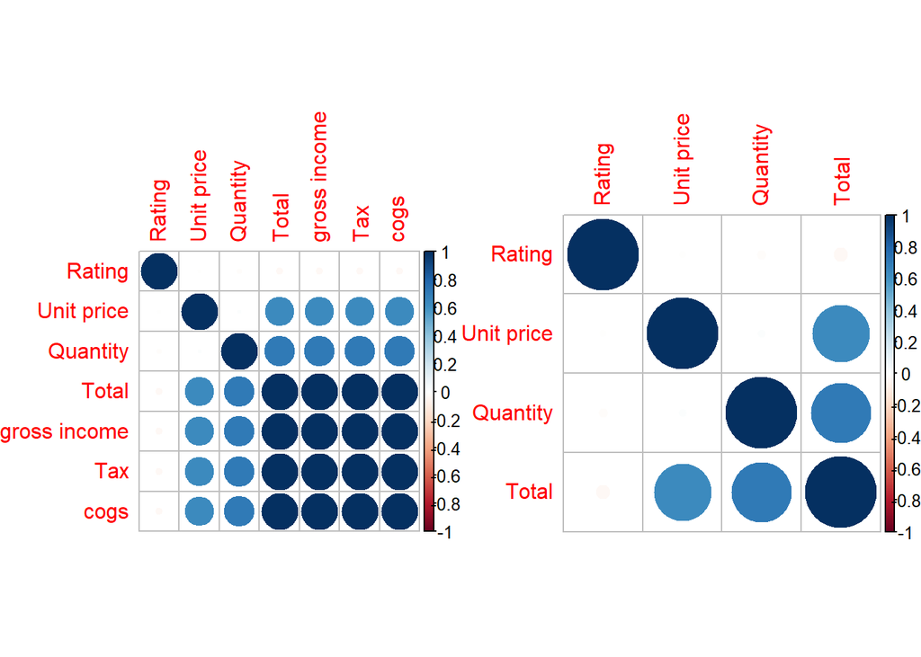

```r
par(mfrow = c(1, 2))
corrplot(correlationMatrix, order = "hclust")

corrplot(cor(df3), order = "hclust")
```

**As we can see, all highly correlated columns have been deducted from our final dataset.**

## Part 3 : Association Analysis

```r
library(arules)
```

**Library Arules It provides the infrastructure for representing, manipulating and analyzing** **transaction data and patterns (frequent itemsets and association rules).**

```r
path = "http://bit.ly/SupermarketDatasetII"
```

```r
goods <- read.transactions(path,sep = ",")
goods
```

```
## transactions in sparse format with
##  7501 transactions (rows) and
##  119 items (columns)
```

**Data has 7501 transactions and 119 items.**

```r
class(goods)
```

```
## [1] "transactions"
## attr(,"package")
## [1] "arules"
```

**The data is of class transactions and contained in the arules package.**

**Check the first 5 transactions under goods dataset.**

```r
inspect(goods[1:5])
```

```
##     items
## [1] {almonds,
##      antioxydant juice,
##      avocado,
##      cottage cheese,
##      energy drink,
##      frozen smoothie,
##      green grapes,
##      green tea,
##      honey,
##      low fat yogurt,
##      mineral water,
##      olive oil,
##      salad,
##      salmon,
##      shrimp,
##      spinach,
##      tomato juice,
##      vegetables mix,
##      whole weat flour,
##      yams}
## [2] {burgers,
##      eggs,
##      meatballs}
## [3] {chutney}
## [4] {avocado,
##      turkey}
## [5] {energy bar,
##      green tea,
##      milk,
##      mineral water,
##      whole wheat rice}
```

**Preview items under goods dataset.**

```r
items<-as.data.frame(itemLabels(goods))
```

**Convert data into a data.frame object.**

```r
colnames(items) <- "Item"
```

**Give column name for output.**

```r
head(items, 10)
```

```
##                 Item
## 1            almonds
## 2  antioxydant juice
## 3          asparagus
## 4            avocado
## 5        babies food
## 6              bacon
## 7     barbecue sauce
## 8          black tea
## 9        blueberries
## 10        body spray
```

**Get the first 10 items under goods dataset.**

```r
summary(goods)
```

```
## transactions as itemMatrix in sparse format with
##  7501 rows (elements/itemsets/transactions) and
##  119 columns (items) and a density of 0.03288973
##
## most frequent items:
## mineral water          eggs     spaghetti  french fries     chocolate
##          1788          1348          1306          1282          1229
##       (Other)
##         22405
##
## element (itemset/transaction) length distribution:
## sizes
##    1    2    3    4    5    6    7    8    9   10   11   12   13   14   15   16
## 1754 1358 1044  816  667  493  391  324  259  139  102   67   40   22   17    4
##   18   19   20
##    1    2    1
##
##    Min. 1st Qu.  Median    Mean 3rd Qu.    Max.
##   1.000   2.000   3.000   3.914   5.000  20.000
##
## includes extended item information - examples:
##              labels
## 1           almonds
## 2 antioxydant juice
## 3         asparagus
```

**The most frequently transacted items are mineral water , eggs and spaghetti.**

**Lets check the frequency of transactions ranging from 10 to 15.**

```r
itemFrequency(goods[, 10:15],type = "absolute")
```

```
##   body spray      bramble     brownies    bug spray burger sauce      burgers
##           86           14          253           65           44          654
```

**Next, we explore the data.**

**We display top 10 most common items in the transactions dataset and the items whose** **relative importance is at least 10 percent**

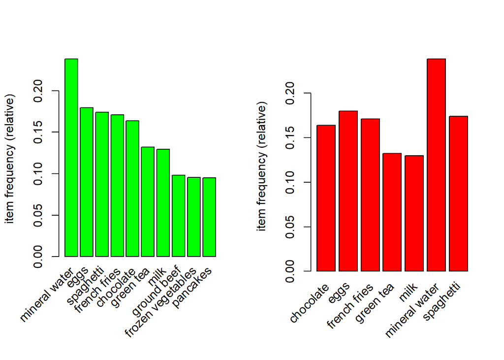

```r
par(mfrow = c(1, 2))


# plot the frequency of items
itemFrequencyPlot(goods, topN = 10,col="green")

# the first plot outputs the top 10 bought items from the data

itemFrequencyPlot(goods, support = 0.1,col="red")
```

**The 2nd plot outputs items with a support ( importance ) of 10 % and above.**

**Now, lets build the associative analysis model rules and give insights.**

**We use the apriori function and set support to 0.001 and confidence to 0.8.**

```r
rules <- apriori (goods, parameter = list(supp = 0.001, conf = 0.8))
```

```
## Apriori
##
## Parameter specification:
##  confidence minval smax arem  aval originalSupport maxtime support minlen
##         0.8    0.1    1 none FALSE            TRUE       5   0.001      1
##  maxlen target  ext
##      10  rules TRUE
##
## Algorithmic control:
##  filter tree heap memopt load sort verbose
##     0.1 TRUE TRUE  FALSE TRUE    2    TRUE
##
## Absolute minimum support count: 7
##
## set item appearances ...[0 item(s)] done [0.00s].
## set transactions ...[119 item(s), 7501 transaction(s)] done [0.00s].
## sorting and recoding items ... [116 item(s)] done [0.00s].
## creating transaction tree ... done [0.00s].
## checking subsets of size 1 2 3 4 5 6 done [0.01s].
## writing ... [74 rule(s)] done [0.00s].
## creating S4 object  ... done [0.00s].
```

```r
rules
```

```
## set of 74 rules
```

**For the first model, there are a set of 74 rules.**

**Lets try different levels of support and confidence and inspect the models.**

```r
rule2 <- apriori (goods, parameter = list(supp = 0.001, conf = 0.6))
```

```
## Apriori
##
## Parameter specification:
##  confidence minval smax arem  aval originalSupport maxtime support minlen
##         0.6    0.1    1 none FALSE            TRUE       5   0.001      1
##  maxlen target  ext
##      10  rules TRUE
##
## Algorithmic control:
##  filter tree heap memopt load sort verbose
##     0.1 TRUE TRUE  FALSE TRUE    2    TRUE
##
## Absolute minimum support count: 7
##
## set item appearances ...[0 item(s)] done [0.00s].
## set transactions ...[119 item(s), 7501 transaction(s)] done [0.00s].
## sorting and recoding items ... [116 item(s)] done [0.00s].
## creating transaction tree ... done [0.00s].
## checking subsets of size 1 2 3 4 5 6 done [0.01s].
## writing ... [545 rule(s)] done [0.00s].
## creating S4 object  ... done [0.00s].
```

```r
rule2
```

```
## set of 545 rules
```

**When confidence reduces to 0.6, we get an increased number of rules, from 74 to 545.**

```r
rule3 <- apriori (goods, parameter = list(supp = 0.002, conf = 0.8))
```

```
## Apriori
##
## Parameter specification:
##  confidence minval smax arem  aval originalSupport maxtime support minlen
##         0.8    0.1    1 none FALSE            TRUE       5   0.002      1
##  maxlen target  ext
##      10  rules TRUE
##
## Algorithmic control:
##  filter tree heap memopt load sort verbose
##     0.1 TRUE TRUE  FALSE TRUE    2    TRUE
##
## Absolute minimum support count: 15
##
## set item appearances ...[0 item(s)] done [0.00s].
## set transactions ...[119 item(s), 7501 transaction(s)] done [0.00s].
## sorting and recoding items ... [115 item(s)] done [0.00s].
## creating transaction tree ... done [0.00s].
## checking subsets of size 1 2 3 4 5 done [0.00s].
## writing ... [2 rule(s)] done [0.00s].
## creating S4 object  ... done [0.00s].
```

```r
rule3
```

```
## set of 2 rules
```

**When we increase the support to about 0.002, the rules drastically reduce to 2.**

**Lets explore the rule.**

```r
summary(rules)
```

```
## set of 74 rules
##
## rule length distribution (lhs + rhs):sizes
##  3  4  5  6
## 15 42 16  1
##
##    Min. 1st Qu.  Median    Mean 3rd Qu.    Max.
##   3.000   4.000   4.000   4.041   4.000   6.000
##
## summary of quality measures:
##     support           confidence        coverage             lift
##  Min.   :0.001067   Min.   :0.8000   Min.   :0.001067   Min.   : 3.356
##  1st Qu.:0.001067   1st Qu.:0.8000   1st Qu.:0.001333   1st Qu.: 3.432
##  Median :0.001133   Median :0.8333   Median :0.001333   Median : 3.795
##  Mean   :0.001256   Mean   :0.8504   Mean   :0.001479   Mean   : 4.823
##  3rd Qu.:0.001333   3rd Qu.:0.8889   3rd Qu.:0.001600   3rd Qu.: 4.877
##  Max.   :0.002533   Max.   :1.0000   Max.   :0.002666   Max.   :12.722
##      count
##  Min.   : 8.000
##  1st Qu.: 8.000
##  Median : 8.500
##  Mean   : 9.419
##  3rd Qu.:10.000
##  Max.   :19.000
##
## mining info:
##   data ntransactions support confidence
##  goods          7501   0.001        0.8
```

**Inspecting the first 5 transactions of the rule.**

```r
inspect(rules[1:5])
```

```
##     lhs                             rhs             support     confidence
## [1] {frozen smoothie,spinach}    => {mineral water} 0.001066524 0.8888889
## [2] {bacon,pancakes}             => {spaghetti}     0.001733102 0.8125000
## [3] {nonfat milk,turkey}         => {mineral water} 0.001199840 0.8181818
## [4] {ground beef,nonfat milk}    => {mineral water} 0.001599787 0.8571429
## [5] {mushroom cream sauce,pasta} => {escalope}      0.002532996 0.9500000
##     coverage    lift      count
## [1] 0.001199840  3.729058  8
## [2] 0.002133049  4.666587 13
## [3] 0.001466471  3.432428  9
## [4] 0.001866418  3.595877 12
## [5] 0.002666311 11.976387 19
```

**If someone buys frozen smoothie and spinach, we have a confidence level of 88 % that they** **will buy mineral water too.**

**Also, if someone purchases mushroom cream sauce and pasta, they have a 95 % likelihood of** **purchasing escalope.**

**We can therefore recommend that the Supermarket advertises escalope to people who purchase** **the combination above.**

**Now, lets order the rule by confidence , sorting it from highest to lowest confidence.**

```r
rules<-sort(rules, by="confidence", decreasing=TRUE)
inspect(rules[1:10])
```

```
##      lhs                       rhs                 support confidence    coverage      lift count
## [1]  {french fries,
##       mushroom cream sauce,
##       pasta}                => {escalope}      0.001066524  1.0000000 0.001066524 12.606723     8
## [2]  {ground beef,
##       light cream,
##       olive oil}            => {mineral water} 0.001199840  1.0000000 0.001199840  4.195190     9
## [3]  {cake,
##       meatballs,
##       mineral water}        => {milk}          0.001066524  1.0000000 0.001066524  7.717078     8
## [4]  {cake,
##       olive oil,
##       shrimp}               => {mineral water} 0.001199840  1.0000000 0.001199840  4.195190     9
## [5]  {mushroom cream sauce,
##       pasta}                => {escalope}      0.002532996  0.9500000 0.002666311 11.976387    19
## [6]  {red wine,
##       soup}                 => {mineral water} 0.001866418  0.9333333 0.001999733  3.915511    14
## [7]  {eggs,
##       mineral water,
##       pasta}                => {shrimp}        0.001333156  0.9090909 0.001466471 12.722185    10
## [8]  {herb & pepper,
##       mineral water,
##       rice}                 => {ground beef}   0.001333156  0.9090909 0.001466471  9.252498    10
## [9]  {ground beef,
##       pancakes,
##       whole wheat rice}     => {mineral water} 0.001333156  0.9090909 0.001466471  3.813809    10
## [10] {frozen vegetables,
##       milk,
##       spaghetti,
##       turkey}               => {mineral water} 0.001199840  0.9000000 0.001333156  3.775671     9
```

**Its interesting to note that customers purchasing cake,meatballs and mineral water almost** **always end up puchasing milk. We would therefore recommend that the Supermarket place** **these items strategically such that they increase the sales of milk.**

**Sticking with milk, say that the supermarket is interested in increasing the sales of milk** **or understanding milk puchases, we can do that by understanding the items customers bought** **before buying milk.**

```r
milk <- subset(rules, subset = rhs %pin% "milk")
```

**Then order by confidence.**

```r
milk<-sort(milk, by="confidence", decreasing=TRUE)
inspect(milk[1:5])
```

```
##     lhs                                  rhs    support     confidence
## [1] {cake,meatballs,mineral water}    => {milk} 0.001066524 1.0000000
## [2] {escalope,hot dogs,mineral water} => {milk} 0.001066524 0.8888889
## [3] {meatballs,whole wheat pasta}     => {milk} 0.001333156 0.8333333
## [4] {black tea,frozen smoothie}       => {milk} 0.001199840 0.8181818
## [5] {burgers,ground beef,olive oil}   => {milk} 0.001066524 0.8000000
##     coverage    lift     count
## [1] 0.001066524 7.717078  8
## [2] 0.001199840 6.859625  8
## [3] 0.001599787 6.430898 10
## [4] 0.001466471 6.313973  9
## [5] 0.001333156 6.173663  8
```

**Customers buying cake, meatballs,burgers,whole wheat pasta and black tea almost always.** **purchased milk.**

## Part 4.

# **Anomaly Detection.**

```r
library(tidyverse)
```

```r
library(anomalize)
library(timetk)
library(tibble)
```

```r
library(tibbletime)
data2 <- fread("http://bit.ly/CarreFourSalesDataset")
```

**Understand the structure of the data.**

```r
str(data2)
```

```
## Classes 'data.table' and 'data.frame':   1000 obs. of  2 variables:
##  $ Date : chr  "1/5/2019" "3/8/2019" "3/3/2019" "1/27/2019" ...
##  $ Sales: num  549 80.2 340.5 489 634.4 ...
##  - attr(*, ".internal.selfref")=<externalptr>
```

**Check for missing data.**

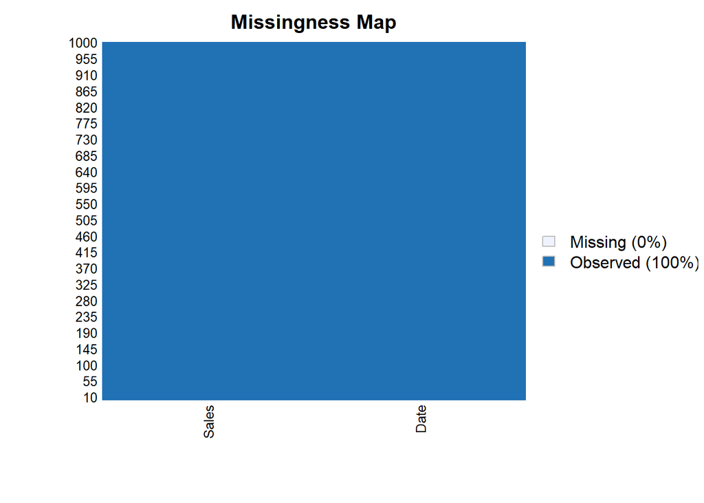

```r
missmap(data2)
```

**No missing values in data.**

**Convert the date character type to an actual DateTime format.**

```r
data2$Date <- as.Date(data2$Date,format = "%m/%d/%y")
```

```r
str(data2)
```

```
## Classes 'data.table' and 'data.frame':   1000 obs. of  2 variables:
##  $ Date : Date, format: "2020-01-05" "2020-03-08" ...
##  $ Sales: num  549 80.2 340.5 489 634.4 ...
##  - attr(*, ".internal.selfref")=<externalptr>
```

**Confirm date data type is imputed.**

```r
dim(data2)
```

```
## [1] 1000    2
```

**Data has 1000 rows and 2 columns.**

```r
duplicated(data2$Date)
```

[output not shown]

[output cut: 69 more lines]

**There are a lot of duplicated dates in data.**

**remove those duplicated dates and there sales figures by aggregating by sum.**

```r
data5<-aggregate(data2$Sales, by=list(data2$Date), sum)
```

```r
head(data5)
```

```
##      Group.1        x
## 1 2020-01-01 4745.181
## 2 2020-01-02 1945.503
## 3 2020-01-03 2078.128
## 4 2020-01-04 1623.688
## 5 2020-01-05 3536.684
## 6 2020-01-06 3614.205
```

```r
dim(data5)
```

```
## [1] 89  2
```

**There are only 89 non- duplicated dates in data.**

**Convert df to a tibble.**

```r
data5 <- as_tibble(data5)
class(data5)
```

```
## [1] "tbl_df"     "tbl"        "data.frame"
```

**Build anomaly deduction model and plot.**

```
## Converting from tbl_df to tbl_time.
## Auto-index message: index = Group.1
```

```
## frequency = 7 days
```

```
## trend = 30 days
```

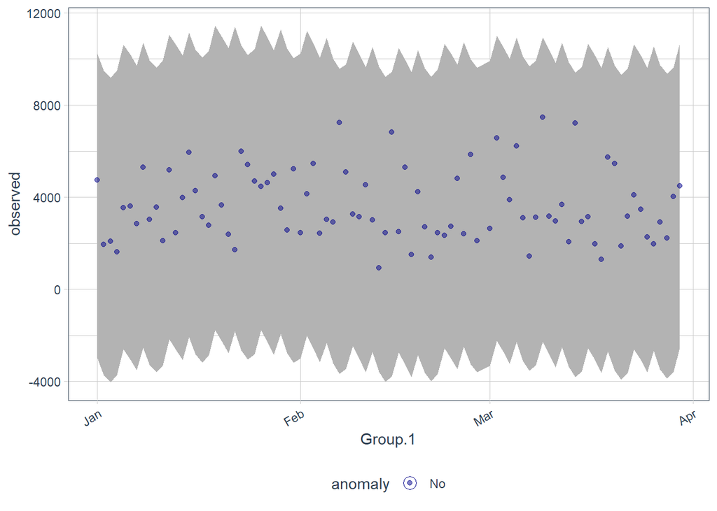

```r
data5 %>%
  time_decompose(x) %>%
  anomalize(remainder) %>%
  time_recompose() %>%
  plot_anomalies(time_recomposed = TRUE, ncol = 2, alpha_dots = 0.5,color_no = "darkblue",color_yes = "red")
```

**From the plot above, there are no anomalies in data.**

**All sales figures seem to be within margins of error.**

**We can plot another anomaly deduction plot as shown.**

```r
df_anomalized <- data5 %>%
  time_decompose(x, merge = TRUE) %>%
  anomalize(remainder) %>%
  time_recompose()
```

```
## Converting from tbl_df to tbl_time.
## Auto-index message: index = Group.1
```

```
## frequency = 7 days
```

```
## trend = 30 days
```

```r
df_anomalized %>% glimpse()
```

```
## Rows: 89
## Columns: 11
## $ Group.1       <date> 2020-01-01, 2020-01-02, 2020-01-03, 2020-01-04, 2020-01~
## $ x             <dbl> 4745.181, 1945.503, 2078.128, 1623.688, 3536.684, 3614.2~
## $ observed      <dbl> 4745.181, 1945.503, 2078.128, 1623.688, 3536.684, 3614.2~
## $ season        <dbl> 595.6079, -215.6459, -610.3359, -351.4537, 696.4782, 210~
## $ trend         <dbl> 2885.719, 2951.906, 3018.092, 3084.279, 3147.297, 3210.3~
## $ remainder     <dbl> 1263.8544, -790.7567, -329.6281, -1109.1372, -307.0912, ~
## $ remainder_l1  <dbl> -6462.091, -6462.091, -6462.091, -6462.091, -6462.091, -~
## $ remainder_l2  <dbl> 6771.022, 6771.022, 6771.022, 6771.022, 6771.022, 6771.0~
## $ anomaly       <chr> "No", "No", "No", "No", "No", "No", "No", "No", "No", "N~
## $ recomposed_l1 <dbl> -2980.764, -3725.831, -4054.334, -3729.265, -2618.316, -~
## $ recomposed_l2 <dbl> 10252.349, 9507.282, 9178.779, 9503.848, 10614.797, 1019~
```

```r
str(df_anomalized$anomaly)
```

```
##  Named chr [1:89] "No" "No" "No" "No" "No" "No" "No" "No" "No" "No" "No" ...
##  - attr(*, "names")= chr [1:89] "25%" "25%" "25%" "25%" ...
```

**As seen, there are no anomalies in the sales figures.**

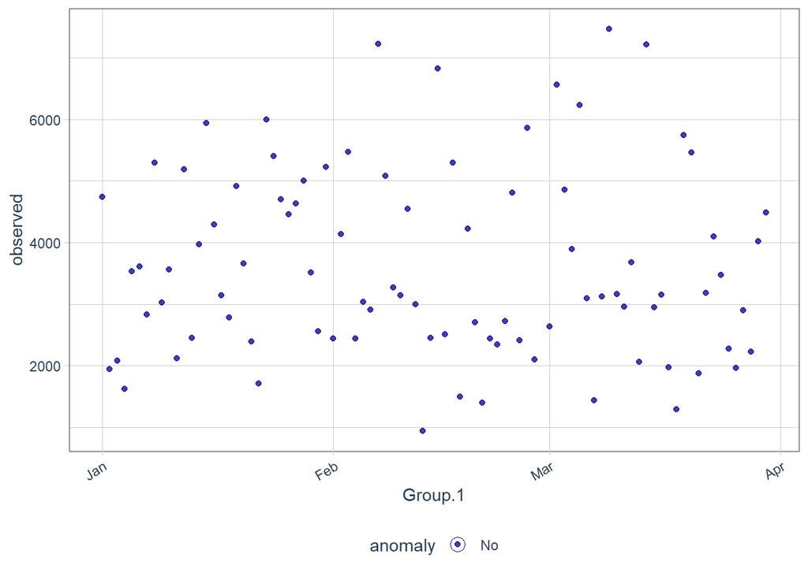

```r
df_anomalized %>% plot_anomalies(ncol = 2, alpha_dots = 0.75,color_no = "darkblue",color_yes = "darkred")
```

**There was no fraud detected from the Supermarket sales figures.**

## 1.9. Recommendations.

**a.) From the models above, we have seen that the most important features / attributes that** **the sales team should consider are Tax and Cogs inorder to increase total sales figures.**

**b.) Health and beauty has the highest average gross income while only recording a few** **transactions while fashion accessories have the lowest average gross income while** **recording more transations.This information is very crucial in determining which** **customers to target.**

**c.) Its interesting to note that customers purchasing cake,meatballs and mineral water** **almost always end up puchasing milk. We would therefore recommend that the Supermarket** **place these items strategically such that they increase the sales of milk.**